# PISA 2012 Explanatory Data Analysis

## by Adrien Funel

## Investigation Overview

In this investigation, we will look into the relationships between study time spent on homeworks and the reading skills of the students. More precisely, we would like to understand which features are favouring the study time to be transformed in success.

## Dataset Overview

The PISA study dataset record features about students across the world from different educational systems. More specifically, it looks at their level of preparation for life beyond school. It also provides features about the students background and attitude toward learning. The records are made of information from about 510,000 students in 65 economies and the assessment of reading, mathematics and science representing about 28 million 15-year-olds globally.

## Distribution of the study time spent on homeworks

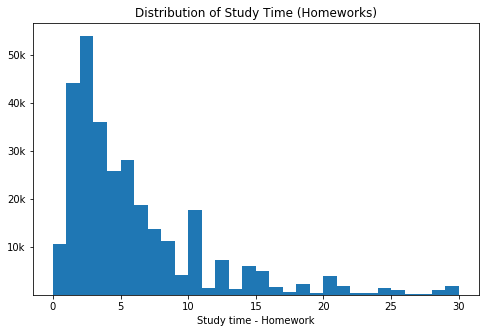

```python
binsize = 1
bins = np.arange(0, df_sub.time_homework.max()+binsize, binsize)

plt.figure(figsize=[8, 5])
plt.hist(data=df_sub, x='time_homework', bins=bins)
plt.title('Distribution of Study Time (Homeworks)')
plt.xlabel('Study time - Homework')
plt.yticks([10000, 20000, 30000, 40000, 50000], ['10k', '20k', '30k', '40k', '50k'])
plt.show()
```

## Reading performance by parent's level of education

We can see how the parent's education level is related to the time spent on homeworks and the reading performance of the children. Specifically, there is a clear effect on the children whose parents are holding a Master / Doctorat. They get better results in reading on average and the higher quartile is spending more time on homeworks than any other category.

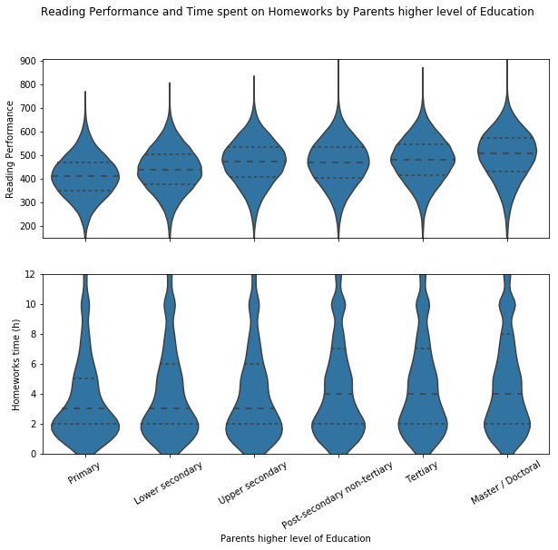

```python
read_per_soc('edu_lvl_parents', sb.color_palette()[0])
```

## Reading Performance by Time spent on Homeworks and Language spoken at Home

We observe a strong correlation of similar intensity between the hours spent on homeworks and the reading performance of the students from both groups (speaking the same language at home than the language of the test and speaking a different language). This reveals that regardless of the language you speak at home, your dedication to homeworks pays back the same way. The only different iis that students speaking a different language at home will have lower results on average for the same number of hours spent on homeworks.

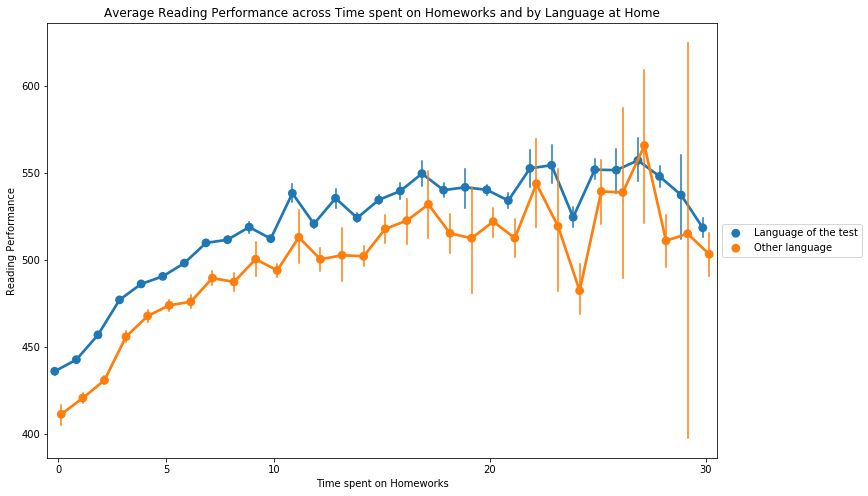

```python
plt.figure(figsize=[12,8])
ax = sb.pointplot(data = df_sub, x = 'time_homework', y = 'perf_read', hue = 'lang_home',
                  dodge = 0.3, errwidth=1.5)
plt.legend(loc = 6, bbox_to_anchor = (1.0, 0.5))
plt.xticks([0, 5, 10, 20, 30],['0', '5', '10', '20', '30'])
plt.xlabel('Time spent on Homeworks')
plt.ylabel('Reading Performance')
plt.title('Average Reading Performance across Time spent on Homeworks and by Language at Home')
plt.show()
```